# Prompt, Run, Verify

Analysis walkthrough · Workshop 3: Using LLMs for Data Analysis in Public Health

Heather Mattie, PhD · Harvard T.H. Chan School of Public Health

September 30, 2026

> **How to use this file.** Every code chunk below is the kind of code an LLM will happily write for you. The *text* between the chunks is the part the LLM can’t do for you: noticing what is wrong. Run each chunk with the green arrow and read the output before moving on. Click **Knit** to turn the whole file into a report.

> **First time?** Put this file and `nhanes_workshop.csv` in the same folder, open the file in RStudio, and run this once in the Console: `install.packages(c("tidyverse", "gtsummary", "flextable", "broom", "rmarkdown"))`

```r
library(tidyverse)   # data import, wrangling, ggplot2
library(gtsummary)   # Table 1 and regression tables
library(flextable)   # export tables to Word / PowerPoint
library(broom)       # tidy model output
```

# 1. Import and first look

**Data:** 1,000 adults sampled from the public `NHANES` R package (2009–2012 survey cycles), reshaped to look like a typical study extract. The codebook is in section 4 of the Student Guide.

```r
dat_raw <- read_csv("nhanes_workshop.csv", show_col_types = FALSE)
glimpse(dat_raw)
```

```
## Rows: 1,000
## Columns: 10
## $ study_id    <chr> "P0001", "P0002", "P0003", "P0004", "P0005", "P0006", "P00…
## $ age         <dbl> 54, 62, 80, 70, 74, 80, 80, 32, 36, 24, 29, 78, 38, 31, 28…
## $ sex         <chr> "male", "female", "male", "male", "female", "female", "fem…
## $ race        <dbl> 2, 2, 1, 1, 1, 1, 1, 5, 3, 1, 5, 1, 4, 4, 1, 4, 4, 1, 1, 3…
## $ education   <chr> "Some College", "High School", "Some College", "College Gr…
## $ bmi         <dbl> 23.8, 27.1, 28.3, 25.9, 26.7, 24.8, 29.7, 23.2, 24.3, 18.1…
## $ sbp         <dbl> 154, 129, NA, 121, 127, 138, 135, 116, 182, 101, 108, 193,…
## $ diabetes    <chr> "Yes", "No", "No", "Yes", "No", "No", "No", "No", "No", "N…
## $ phys_active <chr> "No", "No", "No", "Yes", "Yes", "No", "No", "Yes", "No", "…
## $ ever_smoker <chr> "No", "No", "Yes", "No", "No", "No", "Yes", "No", "No", "Y…
```

**Checkpoint (check 2: right dimensions and types?).** 1,000 rows, 10 columns — good. But `race` is stored as a number (`dbl`). It is a *category* coded 1–5. R does not know that, and neither will the LLM unless you tell it.

```r
summary(dat_raw)
```

```
##    study_id              age            sex                 race
##  Length:1000        Min.   :20.00   Length:1000        Min.   :1.000
##  Class :character   1st Qu.:33.00   Class :character   1st Qu.:1.000
##  Mode  :character   Median :46.00   Mode  :character   Median :1.000
##                     Mean   :47.33                      Mean   :1.906
##                     3rd Qu.:60.00                      3rd Qu.:3.000
##                     Max.   :80.00                      Max.   :5.000
##
##   education              bmi              sbp          diabetes
##  Length:1000        Min.   : 15.80   Min.   : 84.0   Length:1000
##  Class :character   1st Qu.: 24.20   1st Qu.:109.0   Class :character
##  Mode  :character   Median : 28.10   Median :119.0   Mode  :character
##                     Mean   : 37.62   Mean   :121.2
##                     3rd Qu.: 32.60   3rd Qu.:130.0
##                     Max.   :999.00   Max.   :221.0
##                                      NA's   :41
##  phys_active        ever_smoker
##  Length:1000        Length:1000
##  Class :character   Class :character
##  Mode  :character   Mode  :character
##
##
##
##
```

**Checkpoint (check 3: plausible values?).** Mean BMI is about 37.6. That alone might not set off alarms — but the **maximum is 999**. That’s a missing-value code, not a person. The mean was quietly inflated by 9 fake values.

```r
dat_raw |> count(bmi == 999)
```

```
## # A tibble: 2 × 2
##   `bmi == 999`     n
##   <lgl>        <int>
## 1 FALSE          991
## 2 TRUE             9
```

# 2. Clean — the step that needs *you*

These decisions come from the codebook and your domain knowledge, not from the LLM.

```r
dat <- dat_raw |>
  mutate(
    bmi  = na_if(bmi, 999),                       # 999 = missing (codebook)
    race = factor(race, levels = 1:5,
                  labels = c("White", "Black", "Mexican American",
                             "Other Hispanic", "Other/Multiracial")),
    sex  = factor(sex, levels = c("female", "male"),
                  labels = c("Female", "Male")),
    education = factor(education,
                       levels = c("8th Grade", "9 - 11th Grade", "High School",
                                  "Some College", "College Grad")),
    diabetes    = factor(diabetes,    levels = c("No", "Yes")),
    phys_active = factor(phys_active, levels = c("No", "Yes")),
    ever_smoker = factor(ever_smoker, levels = c("No", "Yes"))
  )

summary(dat$bmi)   # now plausible: max 62.8, 9 NA
```

```
##    Min. 1st Qu.  Median    Mean 3rd Qu.    Max.    NA's
##   15.80   24.20   28.10   28.88   32.45   62.80       9
```

# 3. Descriptive statistics

```r
dat |>
  group_by(sex) |>
  summarize(n        = n(),
            mean_age = mean(age),
            mean_bmi = mean(bmi, na.rm = TRUE),
            mean_sbp = mean(sbp, na.rm = TRUE),
            n_missing_sbp = sum(is.na(sbp)))
```

```
## # A tibble: 2 × 6
##   sex        n mean_age mean_bmi mean_sbp n_missing_sbp
##   <fct>  <int>    <dbl>    <dbl>    <dbl>         <int>
## 1 Female   511     48.8     29.1     119.            24
## 2 Male     489     45.8     28.6     123.            17
```

**Checkpoint.** Do the group sizes add to 1,000? Are missing values counted, not silently dropped?

# 4. Visualizations

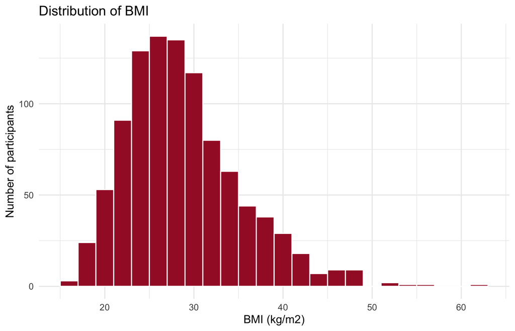

```r
ggplot(dat, aes(x = bmi)) +
  geom_histogram(binwidth = 2, fill = crimson, color = "white") +
  labs(x = "BMI (kg/m2)", y = "Number of participants",
       title = "Distribution of BMI") +
  theme_minimal()
```

```
## Warning: Removed 48 rows containing non-finite outside the scale range
## (`stat_smooth()`).
```

```
## Warning: Removed 48 rows containing missing values or values outside the scale range
## (`geom_point()`).
```

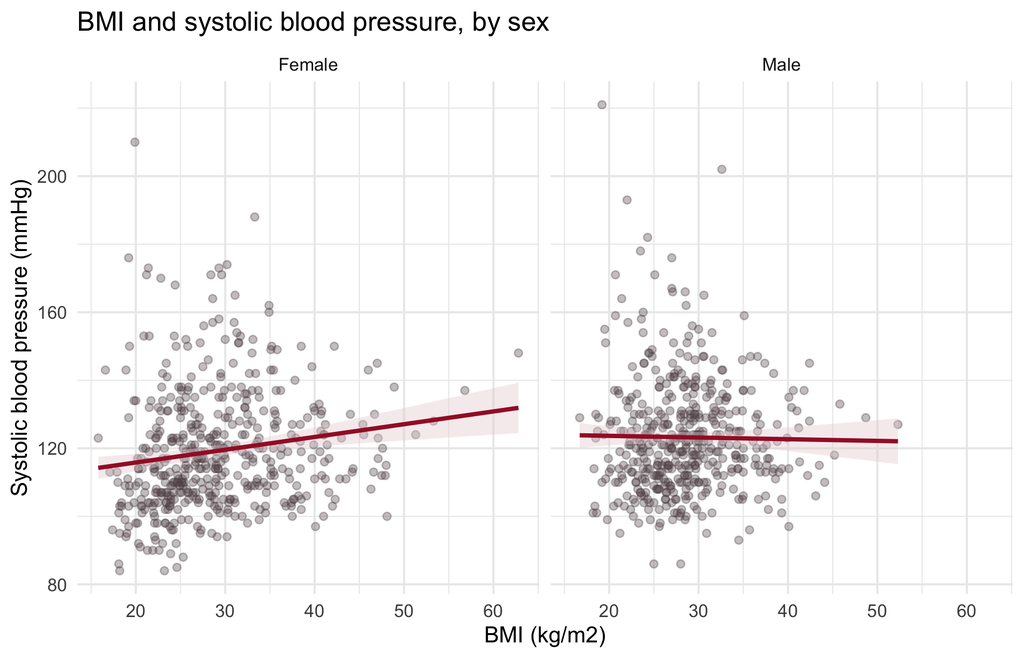

```r
ggplot(dat, aes(x = bmi, y = sbp)) +
  geom_point(alpha = 0.35, color = "#5F5256") +
  geom_smooth(method = "lm", se = TRUE, color = crimson, fill = "#E8D3D7") +
  facet_wrap(~ sex) +
  labs(x = "BMI (kg/m2)", y = "Systolic blood pressure (mmHg)",
       title = "BMI and systolic blood pressure, by sex") +
  theme_minimal()
```

Notice the warning about removed rows: R is telling you some rows had missing BMI or SBP. **Read warnings; don’t scroll past them.**

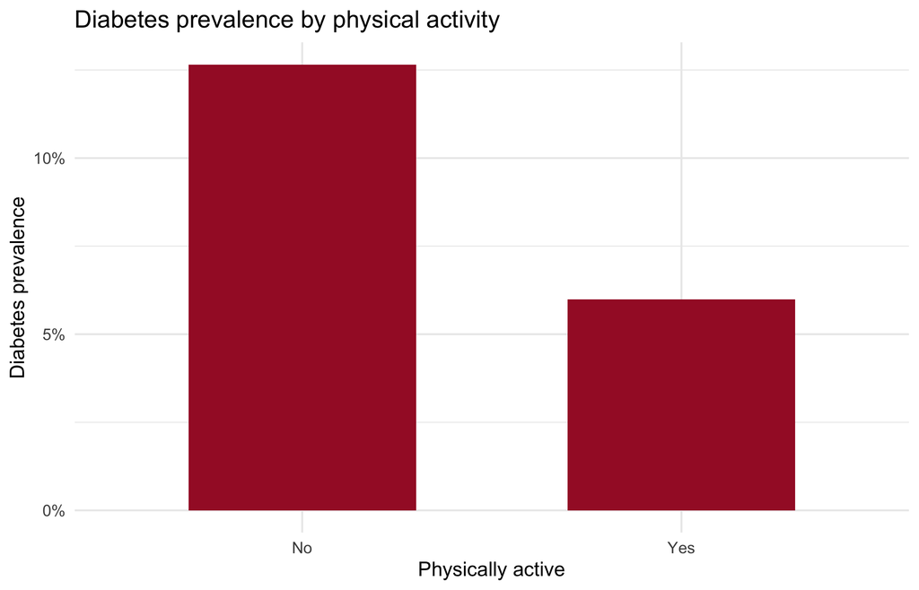

```r
dat |>
  count(phys_active, diabetes) |>
  group_by(phys_active) |>
  mutate(pct = n / sum(n)) |>
  filter(diabetes == "Yes") |>
  ggplot(aes(x = phys_active, y = pct)) +
  geom_col(fill = crimson, width = 0.6) +
  scale_y_continuous(labels = scales::percent) +
  labs(x = "Physically active", y = "Diabetes prevalence",
       title = "Diabetes prevalence by physical activity") +
  theme_minimal()
```

# 5. Table 1

```r
table1 <- dat |>
  select(age, sex, race, education, bmi, sbp, phys_active, ever_smoker, diabetes) |>
  tbl_summary(
    by = diabetes,
    label = list(age ~ "Age (years)", sex ~ "Sex", race ~ "Race/ethnicity",
                 education ~ "Education", bmi ~ "BMI (kg/m2)",
                 sbp ~ "Systolic BP (mmHg)", phys_active ~ "Physically active",
                 ever_smoker ~ "Smoked 100+ cigarettes"),
    statistic = list(all_continuous() ~ "{mean} ({sd})"),
    missing_text = "Missing"
  ) |>
  add_overall() |>
  modify_spanning_header(c("stat_1", "stat_2") ~ "**Diabetes**") |>
  bold_labels()

table1 |> as_flex_table()
```

| Characteristic | Overall N = 1,0001 | Diabetes No N = 9081 | Diabetes Yes N = 921 |
| --- | --- | --- | --- |
| Age (years) | 47 (17) | 46 (17) | 57 (14) |
| Sex |  |  |  |
| Female | 511 (51%) | 471 (52%) | 40 (43%) |
| Male | 489 (49%) | 437 (48%) | 52 (57%) |
| Race/ethnicity |  |  |  |
| White | 592 (59%) | 546 (60%) | 46 (50%) |
| Black | 152 (15%) | 130 (14%) | 22 (24%) |
| Mexican American | 107 (11%) | 98 (11%) | 9 (9.8%) |
| Other Hispanic | 56 (5.6%) | 51 (5.6%) | 5 (5.4%) |
| Other/Multiracial | 93 (9.3%) | 83 (9.1%) | 10 (11%) |
| Education |  |  |  |
| 8th Grade | 82 (8.2%) | 65 (7.2%) | 17 (18%) |
| 9 - 11th Grade | 126 (13%) | 116 (13%) | 10 (11%) |
| High School | 231 (23%) | 208 (23%) | 23 (25%) |
| Some College | 303 (30%) | 276 (30%) | 27 (29%) |
| College Grad | 258 (26%) | 243 (27%) | 15 (16%) |
| BMI (kg/m2) | 29 (6) | 29 (6) | 32 (7) |
| Missing | 9 | 8 | 1 |
| Systolic BP (mmHg) | 121 (18) | 120 (17) | 129 (18) |
| Missing | 41 | 40 | 1 |
| Physically active | 518 (52%) | 487 (54%) | 31 (34%) |
| Smoked 100+ cigarettes | 458 (46%) | 414 (46%) | 44 (48%) |

1Mean (SD); n (%)

**Checkpoint (domain check).** Should Table 1 include p-values? Many journals and methodologists (e.g., CONSORT for trials) say no. The LLM will add them if you ask, and often if you don’t. That’s a *judgment call*, not a coding question.

# 6. Regression models

## Linear regression: systolic BP

```r
fit_lm <- lm(sbp ~ bmi + age + sex + race, data = dat)

tbl_regression(fit_lm,
               label = list(bmi ~ "BMI (per 1 kg/m2)", age ~ "Age (per year)",
                            sex ~ "Sex", race ~ "Race/ethnicity")) |>
  add_glance_source_note(include = c(nobs, r.squared)) |>
  as_flex_table()
```

| Characteristic | Beta | 95% CI | p-value |
| --- | --- | --- | --- |
| BMI (per 1 kg/m2) | 0.14 | -0.01, 0.29 | 0.076 |
| Age (per year) | 0.47 | 0.41, 0.53 | <0.001 |
| Sex |  |  |  |
| Female | — | — |  |
| Male | 5.6 | 3.6, 7.5 | <0.001 |
| Race/ethnicity |  |  |  |
| White | — | — |  |
| Black | 5.0 | 2.1, 7.9 | <0.001 |
| Mexican American | 1.6 | -1.7, 4.9 | 0.3 |
| Other Hispanic | 0.52 | -3.9, 4.9 | 0.8 |
| Other/Multiracial | -1.3 | -4.8, 2.1 | 0.5 |

Abbreviation: CI = Confidence Interval  
No. Obs. = 952; R² = 0.233

**Checkpoint (check 2 again).** Table 1 has 1,000 people. How many are in the model?

```r
nobs(fit_lm)
```

```
## [1] 952
```

Rows with missing BMI or SBP were dropped (complete-case analysis). That should be reported in your methods, and it is a choice worth discussing with your advisor.

## Logistic regression: diabetes

```r
fit_glm <- glm(diabetes ~ bmi + age + sex + phys_active,
               data = dat, family = binomial)

tbl_regression(fit_glm, exponentiate = TRUE,
               label = list(bmi ~ "BMI (per 1 kg/m2)", age ~ "Age (per year)",
                            sex ~ "Sex", phys_active ~ "Physically active")) |>
  as_flex_table()
```

| Characteristic | OR | 95% CI | p-value |
| --- | --- | --- | --- |
| BMI (per 1 kg/m2) | 1.07 | 1.04, 1.11 | <0.001 |
| Age (per year) | 1.04 | 1.03, 1.05 | <0.001 |
| Sex |  |  |  |
| Female | — | — |  |
| Male | 1.81 | 1.15, 2.88 | 0.012 |
| Physically active |  |  |  |
| No | — | — |  |
| Yes | 0.61 | 0.38, 0.98 | 0.043 |

Abbreviations: CI = Confidence Interval, OR = Odds Ratio

**Checkpoint (interpretation).** These are odds ratios, not risk ratios. With about 9% prevalence the two are close here, but the gap grows as an outcome gets more common, and an LLM summary rarely checks. The data are cross-sectional: associations, not effects. LLM summaries often blur both.

# 7. Check 4: test on a tiny example with a known answer

```r
test <- tibble(
  sex = c("F", "F", "F", "M", "M", "M"),
  sbp = c(120, 130, NA, 140, 150, 160)
)
# Expected by hand: F = 125, M = 150
test |> group_by(sex) |> summarize(mean_sbp = mean(sbp, na.rm = TRUE))
```

```
## # A tibble: 2 × 2
##   sex   mean_sbp
##   <chr>    <dbl>
## 1 F          125
## 2 M          150
```

If this returned 83.3 for F, the code would be treating NA as 0. You found the bug on 6 rows instead of in your manuscript.

# 8. Text vs. numbers demo

These are the 25 values from the “Try it” exercise. Paste them into a chat **with code execution turned off** and ask for the mean and standard deviation. Then compare with what R computes below.

```r
set.seed(27)
bp25 <- dat |> filter(!is.na(sbp)) |> slice_sample(n = 25) |> pull(sbp)
cat(bp25, sep = ", ")
```

```
## 130, 118, 100, 119, 96, 90, 120, 148, 114, 130, 99, 124, 131, 130, 148, 98, 118, 114, 113, 134, 116, 143, 158, 112, 110
```

```r
c(mean = mean(bp25), sd = sd(bp25))
```

```
##      mean        sd
## 120.52000  17.41436
```

The model predicts digits that *look like* a mean. Code computes one.

# 9. The no-upload path (restricted data)

When data can’t leave approved systems, give the LLM the **structure**, not the **data**. Example prompt:

> **Context:** I’m working in R with the tidyverse and gtsummary. My data frame `dat` has 1,000 rows. Columns: `age` (numeric, 20–80), `sex` (character: “female”/“male”, lowercase), `race` (integer 1–5; 1=White, 2=Black, 3=Mexican American, 4=Other Hispanic, 5=Other/Multiracial), `bmi` (numeric; 999 = missing), `sbp` (numeric, some NA), `diabetes` (“No”/“Yes”). **Objective:** Create a Table 1 comparing participants with and without diabetes, and fit a linear regression of `sbp` on `bmi`, `age`, `sex`, and `race`. **Format:** One commented R code chunk. First, write code that creates a fake 50-row data frame with this exact structure so I can test the code without real data.

Below is the kind of fake-data code the LLM returns. You develop against it, then run the finished code on the real data **inside the approved environment**.

```r
set.seed(1)
fake <- tibble(
  age      = sample(20:80, 50, replace = TRUE),
  sex      = sample(c("female", "male"), 50, replace = TRUE),
  race     = sample(1:5, 50, replace = TRUE),
  bmi      = c(round(rnorm(48, 28, 6), 1), 999, 999),
  sbp      = c(round(rnorm(48, 120, 15)), NA, NA),
  diabetes = sample(c("No", "Yes"), 50, replace = TRUE, prob = c(.9, .1))
)
glimpse(fake)
```

```
## Rows: 50
## Columns: 6
## $ age      <int> 76, 23, 58, 20, 53, 80, 42, 62, 33, 37, 78, 70, 52, 40, 40, 6…
## $ sex      <chr> "female", "male", "male", "female", "female", "male", "male",…
## $ race     <int> 4, 1, 5, 5, 1, 1, 3, 2, 2, 3, 2, 4, 3, 5, 2, 2, 1, 3, 3, 2, 2…
## $ bmi      <dbl> 24.7, 35.2, 35.0, 32.2, 37.5, 31.4, 20.3, 24.6, 20.7, 25.2, 2…
## $ sbp      <dbl> 110, 119, 91, 138, 95, 113, 103, 109, 151, 120, 101, 95, 127,…
## $ diabetes <chr> "Yes", "No", "No", "No", "No", "No", "No", "No", "No", "No", …
```

Note what made this work: the prompt said “lowercase,” “999 = missing,” and “integer 1–5.” Leave those out and the code will run and be wrong (see Spot the bug in section 5 of the Student Guide).

# 10. Exporting results

Same source, many outputs:

```r
dir.create("output", showWarnings = FALSE)

# Table 1 -> Word and PowerPoint
table1 |> as_flex_table() |> save_as_docx(path = "output/table1.docx")
table1 |> as_flex_table() |> save_as_pptx(path = "output/table1.pptx")

# Regression table -> Word
tbl_regression(fit_lm) |> as_flex_table() |>
  save_as_docx(path = "output/regression_sbp.docx")

# Figure -> PNG (for slides) and PDF (for journals)
p <- ggplot(dat, aes(bmi, sbp)) + geom_point(alpha = .35, color = "#5F5256") +
  geom_smooth(method = "lm", color = crimson, fill = "#E8D3D7") + theme_minimal() +
  labs(x = "BMI (kg/m2)", y = "Systolic BP (mmHg)")
ggsave("output/bmi_sbp.png", p, width = 6, height = 4, dpi = 300)
ggsave("output/bmi_sbp.pdf", p, width = 6, height = 4)
# Clean data -> CSV
write_csv(dat, "output/nhanes_clean.csv")

list.files("output")
```

```
## [1] "bmi_sbp.pdf"         "bmi_sbp.png"         "nhanes_clean.csv"
## [4] "regression_sbp.docx" "table1.docx"         "table1.pptx"
```

**Why this beats downloading a .docx from the chat window:** this file reruns from raw data to final tables. When a reviewer asks you to drop 20 participants, you change one line and knit again.